# Graphical Markov Models with Mixed Graphs in R

# Generating stable mixed graphs

The more general class is that of ribbonless graphs: these are mixed graphs without a specific set of subgraphs called ribbons. Figure 3 below shows two examples of ribbons. The exact definition of ribbons is given in Sadeghi (2012b).

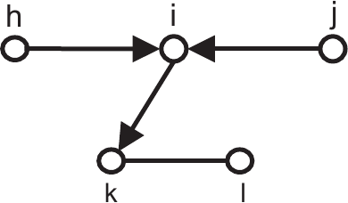

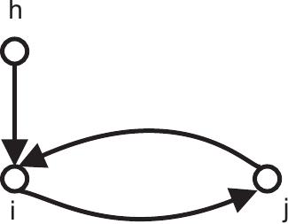

Figure 3: Two commonly seen ribbons h,i,j.

The lack of ribbons ensures that, for any RG, there is a DAG whose independence structure, i.e. the set of all conditional independence statements that it induces after marginalisation over, and conditioning on, two disjoint subsets of its node set can be represented by the given RG. This is essential, as it shows that the independence structures corresponding to RGs are probabilistic, that is, there exists a probability distribution $P$ that is faithful with respect to any RG, i.e. for random vectors $X_A$, $X_B$, and $X_C$ with probability distribution $P$, $X_A \perp \perp X_B\,|\,X_C$ if and only if $\langle A,B\,|\,C\rangle$ is in the induced independence structure by the graph. This probability distribution is the marginal and conditional of a probability distribution that is faithful to the generating DAG.

The other classes of stable graphs are further simplification of the class of ribbonless graphs. Summary graphs have the additional property that there are neither arrowheads pointing to lines (i.e. $\prec \!\!\!\!\!\frac{}{} \!\!\!\!\! \succ\! \circ\, \frac{\;}{}$ or $\frac{ }{ }\!\!\!\!\! \succ \! \circ\, \frac{\;}{}$) nor directed cycles with all arrows pointing towards one direction.

Ancestral graphs have the same constraints as summary graphs plus the additional prohibition of bows, i.e. arcs with one endpoint that is an ancestor of the other endpoint; see Richardson and P. Spirtes (2002).

However, for some ribbonless and summary graphs the corresponding parametrisation is sometimes not available even in the case of a standard joint Gaussian distribution.

If we suppose that stable mixed graphs are only used to represent the independence structure after marginalisation and conditioning, we can consider all types as equally appropriate. However, each of the three types has been used in different contexts and for different purposes. RGs have been introduced in order to straightforwardly deal with the problem of finding a class of graphs that is closed under marginalisation and conditioning by a simple process of deriving them from DAGs. SGs are used when the generating DAG is known, to trace the effects in the sets of regressions as described earlier. AGs are simple graphs, meaning that they do not contain multiple edges and the lack of bows ensures that they satisfy many desirable statistical properties.

In addition, when one traces the effects in regression models with latent and selection variables (as described in the introduction) ribbonless graphs are more alerting to possible distortions (due to indirect effects) than summary graphs, and summary graphs are more alerting than ancestral graphs; see also Wermuth and D. R. Cox (2008). For the exact definition and a thorough discussion of all such graphs, see Sadeghi (2012b).

Sadeghi (2012b) also defines the algorithms for generating stable mixed graphs of a specific type for a given DAG or for a stable mixed graph of the same type after marginalisation and conditioning such that they induce the marginal and conditional DAG-independence structure. We implement these algorithms in this paper.

By “generating graphs” we mean applying the defined algorithms, e.g. those for generating stable mixed graphs to graphs, in order to generate new graphs.

## Functions to generate the three main types of stable mixed graphs

Three main functions `RG`, `SG`, and `AG` are available to generate and plot ribbonless, summary, and ancestral graphs from DAGs, using the algorithms in Sadeghi (2012b). These algorithms look for the paths with three nodes and two edges in the graph whose inner nodes are being marginalised over or conditioned on, and generate appropriate edges between the endpoints. These have two important properties: (a) they are well-defined in the sense that the process can be performed in any order and will always produce the same final graph, and (b) the generated graphs induce the modified independence structure after marginalisation and conditioning; see Sadeghi (2012b) for more details.

The functions `RG`, `SG`, and `AG` all have three arguments: `a`, the given input graph, `M`, the marginalisation set and `C`, the conditioning set. The graph may be of class `"graphNEL"` or of class `"igraph"` or may be represented by a character vector, or by an adjacency matrix, as explained in the previous sections. The sets `M` and `C` (default `c()`) must be disjoint vectors of node labels, and they may possibly be empty sets. The output is always the adjacency matrix of the generated graph. There are two additional logical arguments `showmat` and `plot` to specify whether the adjacency matrix must be explicitly printed (default `TRUE`) and the graph must be plotted (default `FALSE`).

## Some examples

We start from a DAG defined in two ways, as an adjacency matrix and as a character vector:

```r
> ex <- matrix(c(0,1,0,0,0,0,0,0,
                 0,0,1,0,0,0,0,0,
                 0,0,0,0,0,0,0,0,
                 0,0,1,0,1,0,1,0,
                 0,0,0,0,0,1,0,0,
                 0,0,0,0,0,0,0,0,
                 0,0,0,0,0,1,0,0,
                 0,0,0,0,0,1,1,0),
               8, 8, byrow = TRUE)
>
> exvec <- c("a",1,2,"a",2,3,"a",4,3,
             "a",4,5,"a",4,7,"a",5,6,
             "a",7,6,"a",8,6,"a",8,7)
```

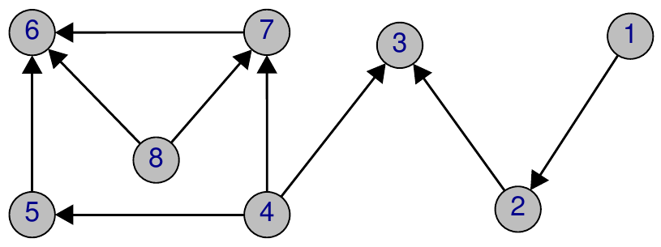

```r
> plotGraph(ex)
```

Then we define two disjoint sets $M$ and $C$ to marginalise over and condition on

```r
> M <- c(5,8)
> C <- 3
```

and we generate the ribbonless, summary and ancestral graphs from the DAG with the associated plot.

```r
> RG(ex, M, C, plot = TRUE)
```

```r
  1  2  4   6   7
1 0  1  0   0   0
2 0  0 10   0   0
4 0 10  0   1   1
6 0  0  0   0 100
7 0  0  0 101   0
```

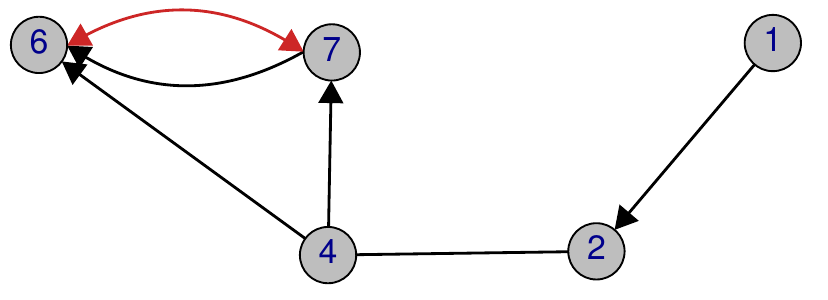

The summary graph is also plotted:

```r
> plotGraph(SG(ex,M,C))
```

```r
   1  2  4   6   7
1  0 10  0   0   0
2 10  0 10   0   0
4  0 10  0   1   1
6  0  0  0   0 100
7  0  0  0 101   0
```

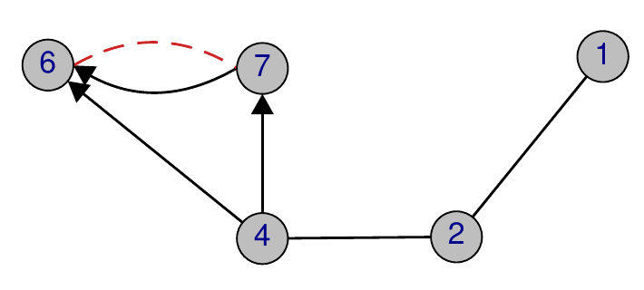

The induced ancestral graph is obtained from the DAG defined as a vector.

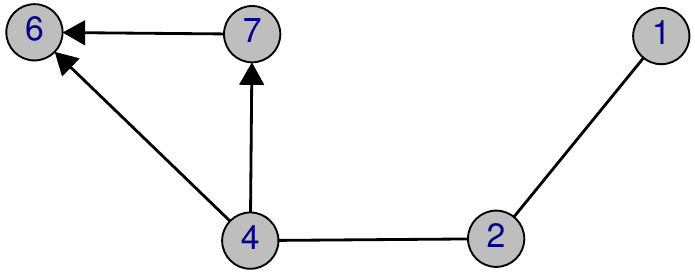

```r
> AG(exvec, M, C, showmat = FALSE, plot = TRUE)
```

# Verifying $m$-separation

To globally verify whether an independence statement of the form $A \perp \perp B \,|\,C$ is implied by a mixed graph we use a separation criterion called $m$-separation. This has been defined in Sadeghi (2012b) for the general class of loopless mixed graphs and is the same as the $m$-separation criterion defined in Richardson and P. Spirtes (2002) for ancestral graphs. It is also a generalisation of the $d$-separation criterion for DAGs (Pearl 1988). This is a graphical criterion that looks to see if the graph contains special paths connecting two sets $A$ and $B$ and involving a third set $C$ of the nodes. These special paths are said to be active or $m$-connecting. For example, a directed path from a node in $A$ to a node in $B$ that does not contain any node of $C$ is $m$-connecting $A$ and $B$. However, if such a path intercepts a node in $C$ then $A$ and $B$ are said to be $m$-separated given $C$. However, this behaviour can change if the path connecting $A$ and $B$ contains a collision node or a collider for short, that is a node $c$ where the edges meet head-to-head, e.g. $\frac{ }{ }\!\!\!\!\! \succ \! c \prec \!\!\!\!\!\frac{}{}$ or $\frac{ }{ }\!\!\!\!\! \succ \! c \prec \!\!\!\!\!\frac{}{} \!\!\!\!\! \succ\!$.

In general, a path is said to be $m$-connecting given $C$ if all its collider nodes are in $C$ or in the set of ancestors of $C$, and all its non-collider nodes are outside $C$. For two disjoint subsets $A$ and $B$ of the node set, we say that $C$ $m$-separates $A$ and $B$ if there is no $m$-connecting path between $A$ and $B$ given $C$.

## Function for verifying $m$-separation

The $m$-separation criterion has been implemented in *ggm* and is available by using the function `msep`. Note that there is still a function `dSep` in *ggm* for $d$-separation, although it is superseded by `msep`.

The function has four arguments, where the first is the graph `a`, in one of the forms discussed before, and the other three are the disjoint sets `A`, `B`, and `C`.

## Examples

```r
> a <- DAG(Y ~ U + Z, X ~ U + W, Z ~ W)
```

We see that $Y$ and $W$ are $m$-separated given $Z$:

```r
> msep(a, "Y", "W", "Z")
```

```r
[1] TRUE
```

and the same statement holds for the induced ancestral graph after marginalisation over `U`:

```r
> b <- AG(a, M = "U")
> msep(b, "Y", "W", "Z")
```

```r
[1] TRUE
```

This was expected because the induced ancestral graph respects all the independence statements induced by $m$-separation in the DAG, and not involving the variable `U`.

As a more complex example, consider the following summary graph,

```r
> a <- makeMG(dg= DG(W ~ Z, Z ~ Y + X),
              bg= UG(~ Y*Z))
```

[figure not shown]

```r
> plotGraph(a)
```

Then, the two following statements verify whether `X` is $m$-separated from `Y` given `Z`, and whether `X` is $m$-separated from `Y` (given the empty set):

```r
> msep(a, "X", "Y", "Z")
```

```r
[1] FALSE
```

```r
> msep(a, "X", "Y")
```

```r
[1] TRUE
```

# Verifying maximality

For many subclasses of graphs a missing edge corresponds to some independence statement, but for the more complex classes of mixed graphs this is not necessarily true. A graph where each of its missing edges is related to an independence statement is called a maximal graph. For a more detailed discussion on maximality of graphs and graph-theoretical conditions for maximal graphs, see Richardson and P. Spirtes (2002) and Sadeghi and S. L. Lauritzen (2012). Sadeghi and S. L. Lauritzen (2012) also gave an algorithm for generating maximal ribbonless graphs that induces the same independence structure as an input non-maximal ribbonless graph. This algorithm has been implemented in *ggm* as illustrated below.

## Function for generating maximal graphs

```r
> H <- matrix(c(0  ,100,  1,  0,
                100,0  ,100,  0,
                0  ,100,  0,100,
                0,  1  ,100,  0), 4, 4)
```

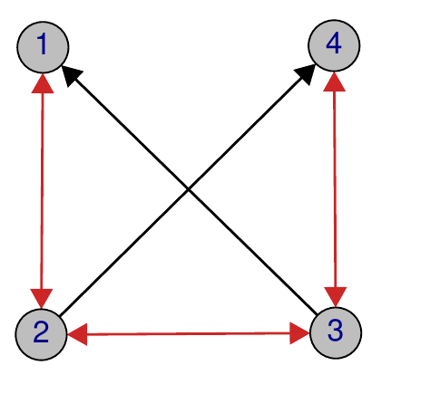

```r
> plotGraph(H)
```

is a non-maximal ancestral graph, with the missing edge between nodes 1 and 4 that is not associated with any independence statement. Its associated maximal graph is obtained by

```r
> Max(H)
```

```r
    1   2   3   4
1   0 100   0 100
2 100   0 100   1
3   1 100   0 100
4 100   0 100   0
```

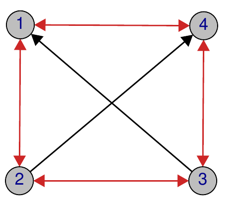

```r
> plotGraph(Max(H))
```

As the graph `H` is an ancestral graph (as may be verified by the function `isAG`), we obtain the same result with

```r
> MAG(H)
```

```r
    1   2   3   4
1   0 100   0 100
2 100   0 100   1
3   1 100   0 100
4 100   0 100   0
```

# Verifying Markov equivalence

Two graphical models are said to be Markov equivalent when their associated graphs, although nonidentical, imply the same independence structure, that is the same set of independence statements. Thus two Markov equivalent models cannot be distinguished on the basis of statistical tests of independence, even for arbitrary large samples. For instance, it is easy to verify that the two directed acyclic graphs models $X \prec \!\!\!\!\!\frac{}{}U \frac{ }{ }\!\!\!\!\! \succ \! Y$ and $X \prec \!\!\!\!\!\frac{}{}U \prec \!\!\!\!\!\frac{}{}Y$ both imply the same independence statements, and are, therefore, Markov equivalent.

Sometimes, we can check whether graphs of different types are Markov equivalent. For instance the DAG $X \frac{ }{ }\!\!\!\!\! \succ \! U \prec \!\!\!\!\!\frac{}{}Y$ is Markov equivalent to the bi-directed graph $X \prec \!\!\!\!\!\frac{}{} \!\!\!\!\! \succ\! U \prec \!\!\!\!\!\frac{}{} \!\!\!\!\! \succ\! Z$.

Markov equivalent models may be useful in applications because (a) they may suggest alternative interpretations of a given well-fitting model or (b) on the basis of the equivalence one can choose a simpler fitting algorithm. For instance, the previous bi-directed graph model may be fitted, using the Markov equivalent DAG, in terms of a sequence of univariate regressions.

In the literature several problems related to Markov equivalences have been discussed. These include (a) verifying the Markov equivalence of given graphs, (b) presenting conditions under which a graph of a specific type can be Markov equivalent to a graph of another type, and (c) providing algorithms for generating Markov equivalent graphs of a certain type from a given graph.

## Functions for testing Markov equivalences

The function `MarkEqRcg` tests whether two regression chain graphs are Markov equivalent. This function simply finds the skeleton and all unshielded collider V-configurations in both graphs and tests whether they are identical, see Wermuth and K. Sadeghi (2012). The arguments of this function are the two graphs `a` and `b` in one of the allowed forms. For example,

```r
> H1 <- makeMG(dg = DAG(W ~ X, Q ~ Z),
               bg = UG(~ X*Y + Y*Z + W*Q))
> H2 <- makeMG(dg = DAG(W ~ X, Q ~ Z, Y ~ X + Z),
               bg = UG(~ W*Q))
> H3 <- DAG(W ~ X, Q ~ Z + W, Y ~ X + Z)
```

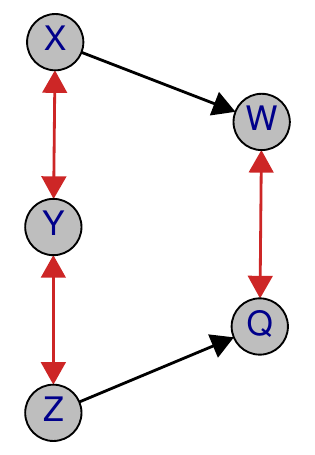

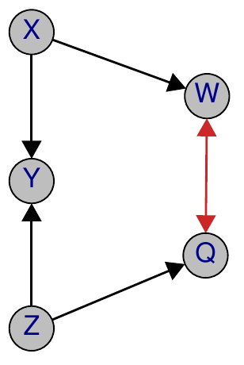

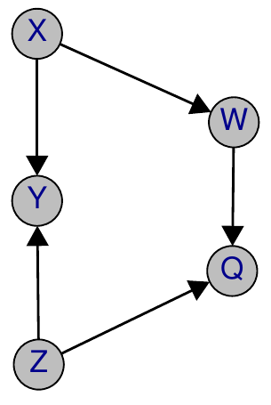

```r
> plotGraph(H1); plotGraph(H2); plotGraph(H3)
```

We can now verify Markov equivalence as follows

```r
> MarkEqRcg(H1,H2)
```

```r
[1] TRUE
```

```r
> MarkEqRcg(H1,H3)
```

```r
[1] FALSE
```

```r
> MarkEqRcg(H2,H3)
```

```r
[1] FALSE
```

To test Markov equivalence for maximal ancestral graphs the algorithm is much more computationally demanding (see Ali and T. Richardson (2004)) and, for this purpose, the function `MarkEqMag` has been provided. Of course, one can use this function for Markov equivalence of regression chain graphs (which are a subclass of maximal ancestral graphs). For example,

```r
> A1 <- makeMG(dg = DG(W ~ Y),
               bg = UG(~ X*Y + Y*Z + Z*W))
> A2 <- makeMG(dg = DG(W ~ Y, Y ~ X),
               bg = UG(~ Y*Z + Z*W))
> A3 <- makeMG(dg = DG(W ~ Y, Y ~ X, Z ~ Y),
               bg = UG(~ Z*W))
```

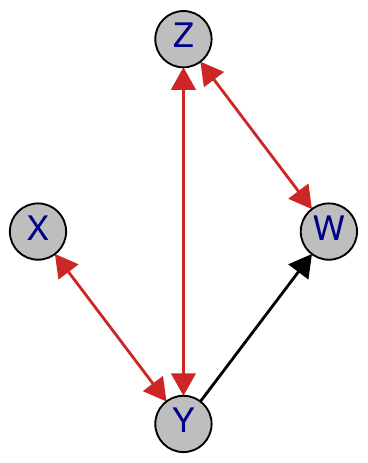

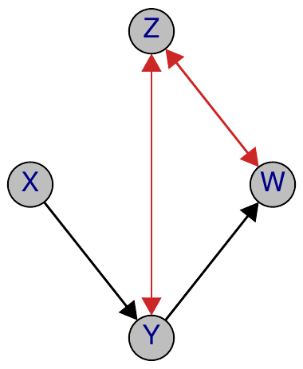

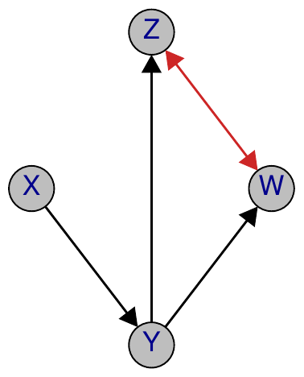

```r
> plotGraph(A1); plotGraph(A2); plotGraph(A3)
```

```r
> MarkEqMag(H1,H2)
```

```r
[1] TRUE
```

```r
> MarkEqMag(H1,H3)
```

```r
[1] FALSE
```

```r
> MarkEqMag(H2,H3)
```

```r
[1] FALSE
```

## Functions for generating Markov equivalent graphs of a specific type

To obtain an alternative interpretation of an independence structure by using different graphical models, it is important to verify if a given graph is capable of being Markov equivalent to a graph of a specific class of graphs (such as DAGs, undirected graphs, or bidirected graphs), and if so, to obtain as a result such a graph. The functions `RepMarDAG`, `RepMarUG`, and `RepMarBG` do this for DAGs, undirected graphs, and bidirected graphs, respectively. For associated conditions and algorithms, see Sadeghi (2012a). For example, given the following graph

```r
> H <- matrix(c( 0,10,  0,  0,
                10, 0,  0,  0,
                 0, 1,  0,100,
                 0, 0,100,  0), 4, 4)
```

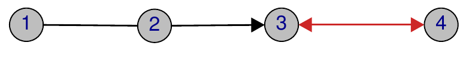

```r
> plotGraph(H)
```

we can see that it is Markov equivalent to a DAG, by

```r
> RepMarDAG(H)
```

```r
$verify
[1] TRUE

$amat
  1 2 3 4
1 0 1 0 0
2 0 0 1 0
3 0 0 0 0
4 0 0 1 0
```

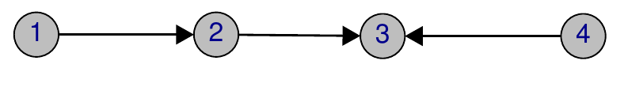

```r
> plotGraph(RepMarDAG(H))
```

On the other hand it is not Markov equivalent to an undirected graph or to a bidirected graph.

```r
> RepMarUG(H)
```

```r
$verify
[1] FALSE

$amat
[1] NA
```

```r
> RepMarBG(H)
```

```r
$verify
[1] FALSE

$amat
[1] NA
```

# Acknowledgments

The authors are grateful to Steffen Lauritzen for helpful suggestions on codes and comments on an earlier version of the paper and to Nanny Wermuth, the editor, and referees for their insightful comments.

Ali and T. Richardson, R. A. 2004. *Searching across Markov equivalence classes of maximal ancestral graphs*. In Proceedings of the Joint Statistical Meeting of theAmerican Statistical Association Toronto Canada.

Cox and N. Wermuth, D. R. 1996. *Multivariate Dependencies : models, analysis and interpretation*. Chapman & Hall London United Kingdom.

Csardi and T. Nepusz, G. 2006. *The "igraph" software package for complex network research*. InterJournal Complex Systems: 1695. http://igraph.sf.net.

Dethlefsen and S. Højsgaard, C. 2005. *A common platform for graphical models in R: The gRbase package*. Journal of Statistical Software 14 (17): 12 ISSN 1548-7660. http://www.jstatsoft.org/v14/i17.

Gentleman, E. Whalen, W. Huber, and S. Falcon, R. 2012. *graph: A package to handle graph data structures,* . R package version 1.36.0.

Højsgaard, D. Edwards, and S. Lauritzen, S. 2012. *Graphical Models with R*. Springer-Verlag Berlin-Heidelberg-New York.

Højsgaard, S. 2012. *Graphical independence networks with the gRain package for R*. Journal of Statistical Software 46 (10): http://www.jstatsoft.org/v46/i10/.

Koster, J. T. A. 2002. *Marginalizing and conditioning in graphical models*. Bernoulli 8 (6):

Marchetti, G. M. 2006. *Independencies induced from a graphical Markov model after marginalization and conditioning: the R package ggm*. Journal of Statistical Software 15 (6).

Marchetti, M. Drton, and K. Sadeghi, G. M. 2012. *ggm: A package for Graphical Markov Models,* . R package version 1.995-3. http://CRAN.R-project.org/package=ggm.

Pearl, J. 1988. *Probabilistic Reasoning in Intelligent Systems: networks of plausible inference*. Morgan Kaufmann Publishers San Mateo CA USA.

Richardson and P. Spirtes, T. S. 2002. *Ancestral graph Markov models*. Annals of Statistics 30 (4):

Sadeghi and S. L. Lauritzen, K. 2012. *Markov properties for mixed graphs*. Bernoulli to appear. http://arxiv.org/abs/1109.5909.

Sadeghi, K. 2012a. *Markov equivalences for subclasses of mixed graphs*. Submitted natexlabb. http://arxiv.org/abs/1110.4539.

———. 2012b. *Stable mixed graphs*. Bernoulli to appear natexlaba. http://arxiv.org/abs/1110.4168.

Wermuth and D. R. Cox, N. 2008. *Distortion of effects caused by indirect confounding*. Biometrika 95:

Wermuth and K. Sadeghi, N. 2012. *Sequences of regressions and their independences*. TEST 21 (2):; 274–279.

Wermuth, N. 2011. *Probability distributions with summary graph structure*. Bernoulli 17 (3):